# Income Tax Paper

March, 1st 2016

```r
# Start Fresh
cat("\014")
```

```r
rm(list=ls())
setwd("/Users/hectorbahamonde/RU/Dissertation/Papers/IncomeTaxAdoption")

# Load Datasets
load("/Users/hectorbahamonde/RU/Dissertation/Papers/IncomeTaxAdoption/incometax_data.RData") # Load data
load("/Users/hectorbahamonde/RU/Dissertation/Papers/IncomeTaxAdoption/cox.RData") # Cox
load("/Users/hectorbahamonde/RU/Dissertation/Papers/IncomeTaxAdoption/L_cox.RData") # Lagged Data for Cox
load("/Users/hectorbahamonde/RU/Dissertation/Papers/IncomeTaxAdoption/logitgee.RData") # Logit GEE
load("/Users/hectorbahamonde/RU/Dissertation/Papers/IncomeTaxAdoption/ag_data.RData") # For Multiple Non Competing Hazard Ratios
load("/Users/hectorbahamonde/RU/Dissertation/Papers/IncomeTaxAdoption/l_clogit.RData") # Lagged CONSTANT AGR MANUFACT for clogit  (fixed effects)

# Loading/Installing Library
# install.packages("survival")
library(survival) # Cox Models
# install.packages("stargazer")
library(stargazer, quietly = TRUE) # Tables
# install.packages("knitr")
library(knitr) # KNITR, replicable research package
opts_chunk$set(fig.width=10, fig.height=5)


### Feb. 15th, 2016, Zelig wasn't loading the (1) graph nor the (2) Rgraphviz, so I loaded them individually
### It seemed that these two packages were not available for my R version on CRAN. They were available for latest R from source, though
### source("https://bioconductor.org/biocLite.R")
### biocLite("graph")
### source("https://bioconductor.org/biocLite.R")
### biocLite("Rgraphviz")

# install.packages("devtools")
# library(devtools)
# install_github("IQSS/Zelig")
library(Zelig)
```

General specifications:

When “cluster” is on: It’s to create a “robust variance matrix”. Sort of corrects inter-temporal correlation, right?

When I lagged covariate, I use a different data set. I made sure this one was right.

These models are mostly Cox Proportional Hazard Models (to predict “when” income taxation was imposed, conditional on covariates).

For the “Recurrent Events” model: COX PH models predict one thing. RE predict the joint appearance of two (or more things) - essentially, multiple failure-time events. In my case, my theory says, basically, “no taxation without representation”. So I predict the jointly appearance of DEMOCRACY and INCOME taxation (and it worked!). These models are called “Andersen-Gill Models”.

Many people, including J. Box-Steffensmeier, recommend to “transform” variables (in log scale) to account for time dynamics. Splines are also recommended, but I didn’t try this. Other transformation are possible within the “time transformed” (tt) argument. “A time-transform term allows variables to vary dynamically in time”. That sounds as a non-linear/flexible transformation?

Besides COX PH I tried “Logit Generalized Estimating Equations” (tax=1, no tax = 0). “The GEE logit estimates the same model as the standard logit regression. Unlike in logit regression, GEE logit allows for dependence within clusters, such as in longitudinal data”.

I also tried “conditional logits”, these are the homologous to “fixed effects logit” models.

```r
# Here below are the models

## Model with "time-transformed" variables
cox1.tt = coxph(Surv(year, incometax.s) ~ tt(constmanufact) + tt(constagricult) + cluster(country),
                data=cox, x=T
)

##  Model with logged independent variables
cox2 = coxph(Surv(year, incometax.s) ~ log(constmanufact) + log(constagricult) + log(totpop) + cluster(country),
             data=cox
)


## Another possible transformation is to lag the independent variables
### Here I use a data set that is lagged.
cox.L = coxph(Surv(year, incometax.s) ~ log(constmanufact.L) + log(constagricult.L) + log(totpop) + cluster(country),
              data=L.cox)


## Logit Generalized Estimating Equations
logitgee.1 = zelig(incometax.d ~ ln.constmanufact + ln.constagricult + ln.totpop,
                   model = "logit.gee",
                   id = "country",
                   cite = FALSE,
                   data = logitgee)


# Multiple Failures: Income Tax AND Democracy
## Here the panel ends when both democracy AND income tax appear. Both events are "1". So each panel has two 1s.
cox2.ag = coxph(Surv(year, dem.tax) ~ log(constmanufact) + log(constagricult) + log(urbpop) + cluster(country),
                data=ag.data
)


# Conditional Logit (FE model)
clogit.1 = clogit(incometax.d ~  log(constmanufact) + log(constagricult) +strata(country), method= "efron", data = data)
```

And now this is the table.

```r
# This here is to write the table
stargazer(cox1.tt, cox2, cox.L, clogit.1, cox2.ag, #logitgee.1,
          type = "text", # change to "latex"/"text" when nedded
          covariate.labels=c(
                  "Manufacture Output$_{tt}$",
                  "Agricultural Output$_{tt}$",
                  "Manufacture Output  \\emph{(ln)}",
                  "Agricultural Output  \\emph{(ln)}",
                  "Manufacture Output t-1  \\emph{(ln)}",
                  "Agricultural Output t-1  \\emph{(ln)}",
                  "Total Population  \\emph{(ln)}",
                  "Urban Population  \\emph{(ln)}"
                  ),
          column.labels = c("Cox PH", "Cond. Logit", "Andersen-Gill"),
          column.separate = c(3, 1, 1),
          model.names = F,
          column.sep.width = "2pt",
          dep.var.labels=c("Income Taxation", "", "Taxation and Democracy"),
          dep.var.labels.include = T, # edit this one to get rid of the annoying model titles
          add.lines = list(
                  c("FE", "No", "No", "No", "Yes", "No"),
                  c("Transformation", "Time-dependent Covariates", "Logged Covariates", "Lagged Covariates", "Logged Covariates", "Logged Covariates")
                  ),
          label = "results:1",
          notes = "Robust Std. Errors in Parentheses",
          title = "Structural Origins of Income Taxation",
          font.size = "tiny",
          table.placement = "h",
          notes.align = "c",
          style = "apsr")
```

```
##
## Structural Origins of Income Taxation
## ----------------------------------------------------------------------------------------------------------------------------------------
##                                                      Income Taxation                                             Taxation and Democracy
##                                                           Cox PH                                 Cond. Logit         Andersen-Gill
##                                         (1)                    (2)                (3)                 (4)                  (5)
## ----------------------------------------------------------------------------------------------------------------------------------------
## Manufacture Outputtt                 0.279***
##                                       (0.098)
## Agricultural Outputtt                -0.249***
##                                       (0.094)
## Manufacture Output (ln)                                     31.644***                              0.921***              5.063**
##                                                             (29.726)                                (0.157)              (4.716)
## Agricultural Output (ln)                                   -24.256***                               -0.433*              -9.908**
##                                                             (22.231)                                (0.230)              (7.628)
## Manufacture Output t-1 (ln)                                                    47.504***
##                                                                                 (61.557)
## Agricultural Output t-1 (ln)                                                   -35.990***
##                                                                                 (45.825)
## Total Population (ln)                                       61.984***          93.500***
##                                                             (59.439)           (123.003)
## Urban Population (ln)                                                                                                     -0.975
##                                                                                                                          (3.034)
## FE                                      No                     No                  No                 Yes                   No
## Transformation               Time-dependent Covariates  Logged Covariates  Lagged Covariates   Logged Covariates    Logged Covariates
## N                                       181                    181                174                 621                   48
## R2                                     0.111                  0.212              0.221               0.323                0.089
## Max. Possible R2                       0.235                  0.235              0.243               0.996                0.319
## Log Likelihood                        -13.627                -2.771              -2.435           -1,622.076              -6.983
## Wald Test                       28.270*** (df = 2)     121.380*** (df = 3) 82.830*** (df = 3) 197.080*** (df = 2)   26.130*** (df = 3)
## LR Test                         21.305*** (df = 2)     43.018*** (df = 3)  43.549*** (df = 3) 242.338*** (df = 2)     4.479 (df = 3)
## Score (Logrank) Test            109.733*** (df = 2)    24.332*** (df = 3)  24.970*** (df = 3) 235.439*** (df = 2)     5.331 (df = 3)
## ----------------------------------------------------------------------------------------------------------------------------------------
##                                                      *p < .1; **p < .05; ***p < .01
##                                                    Robust Std. Errors in Parentheses
```

Here, the first three columns are COX PH, 4th column is conditional logit (“fe”), and 5th column is COX but for multiple failures (democrcy and taxation)

And here below is the Logit GEE model (which the stargazer table package doesn’t read)

```r
summary(logitgee.1)
```

```
## Model:
##
## Call:
## z5$zelig(formula = incometax.d ~ ln.constmanufact + ln.constagricult +
##     ln.totpop, id = "country", data = logitgee)
##
##  Coefficients:
##                  Estimate  Std.err   Wald Pr(>|W|)
## (Intercept)      -43.5177  12.3233 12.470 0.000413
## ln.constmanufact   2.6395   0.9496  7.727 0.005441
## ln.constagricult  -2.6051   1.0984  5.625 0.017709
## ln.totpop          5.4323   1.8371  8.744 0.003106
##
## Estimated Scale Parameters:
##             Estimate Std.err
## (Intercept)   0.3409  0.1548
##
## Correlation: Structure = independenceNumber of clusters:   7   Maximum cluster size: 110
## Next step: Use 'setx' method
```

Now, lets try some post estimations

COX PH assume that the haxards, are, “proportional”. Lets see if this assumption is “correct”

```r
## Testing Prop. Assumption
test.assumption = cox.zph(cox2, transform = 'log')
print(test.assumption)
```

```
##                        rho    chisq     p
## log(constmanufact)  0.0213 0.000706 0.979
## log(constagricult) -0.0409 0.003579 0.952
## log(totpop)         0.0987 0.021272 0.884
## GLOBAL                  NA 0.347609 0.951
```

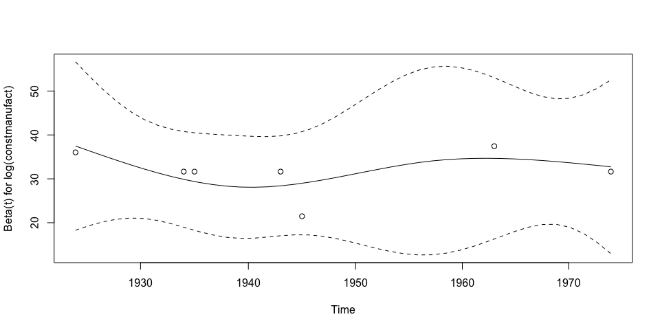

```r
plot(test.assumption[1]) # Industry
```

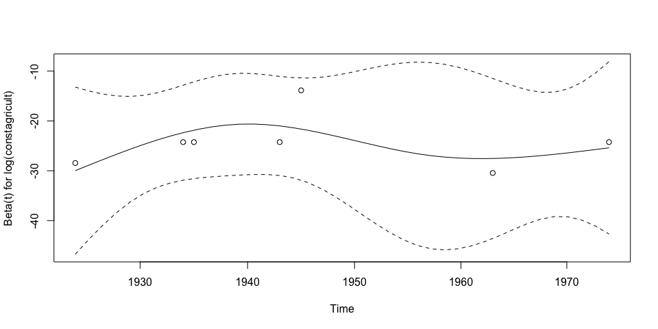

```r
plot(test.assumption[2]) # Agriculture
```

If the proportional hazards assumption is true, beta(t) will be a horizontal line. The printout gives a test for slope=0. A p-value less than 0.05 indicates a violation of the proportionality assumption. Safe to say the assumption holds

We can also simulate quantities of interest.

```r
# Load the libraries
## devtools::install_github('christophergandrud/simPH')
library(simPH)

# I use non-logged covariates for simulation (since it seems that the sim function doesn't take well natural logs)
cox3 = coxph(Surv(year, incometax.s) ~ constmanufact + constagricult + totpop + cluster(country),
             data=cox
)

# Show the table.
stargazer(cox3,
          type = "text", # change to "latex"/"text" when nedded
          #covariate.labels=c("Agr/Ind Proportion"),
          dep.var.labels=c("Income Taxation"),
          label = "results:1",
          notes = "Robust Std. Errors in Parentheses",
          title = "Structural Origins of Income Taxation",
          font.size = "scriptsize",
          table.placement = "h",
          notes.align = "c",
          style = "apsr")
```

```
##
## Structural Origins of Income Taxation
## ---------------------------------------
##                       Income Taxation
## ---------------------------------------
## constmanufact             0.006***
##                           (0.003)
## constagricult            -0.002***
##                           (0.001)
## totpop                    0.004***
##                           (0.002)
## N                           181
## R2                         0.183
## Max. Possible R2           0.235
## Log Likelihood             -5.993
## Wald Test            35.230*** (df = 3)
## LR Test              36.570*** (df = 3)
## Score (Logrank) Test 54.030*** (df = 3)
## ---------------------------------------
##     *p < .1; **p < .05; ***p < .01
##    Robust Std. Errors in Parentheses
```

```r
# Simulate the RELATIVE HAZARD for a sequence that goes from MIN to the MAX of the Industrial Output
sim3.m <- coxsimLinear(cox3,
                       b = "constmanufact",
                       qi = "Relative Hazard",
                       Xj = seq(min(cox$constmanufact), max(cox$constmanufact), by=250)
                       )
```

```
## All Xl set to 0.
```

```
## 15703 (62.8%) simulations dropped for having
## quantity of interest values: Inf/NA/NaN/>1000000.
##
## To keep extreme values set extremesDrop = FALSE.
```

```r
# Simulate the RELATIVE HAZARD for a sequence that goes from MIN to the MAX of the Agricultural Output
sim3.a <- coxsimLinear(cox3,
                       b = "constagricult",
                       qi = "Relative Hazard",
                       Xj = seq(min(cox$constagricult), max(cox$constagricult), by=150)
                       )
```

```
## All Xl set to 0.
```

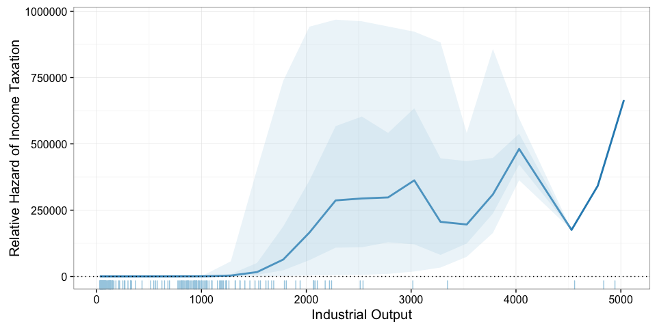

```r
# It says "All Xl set to 0" b/c it sets the reference category to 0.
# Hazard ratios are COMPARISONS, so the coefficients mean the effects of the Betas, relative to 0.

# Plot
## IMPORTANT! A relative hazard for a unit at zero is always one, as it is a ratio of the hazards with itself. Gandrud2015 p. 10
simGG(sim3.m, xlab = "Industrial Output", ylab="Relative Hazard of Income Taxation")
```

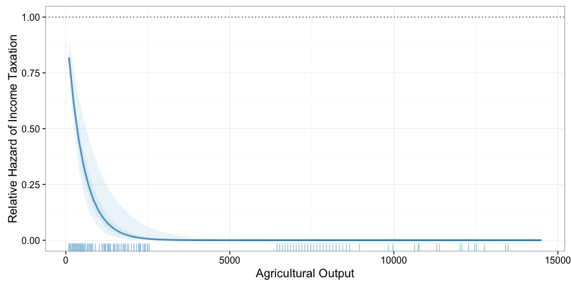

```r
simGG(sim3.a, xlab = "Agricultural Output", ylab="Relative Hazard of Income Taxation")
```